# original hufkens

##1. The original Hufken’s PhenoGrass Model

Key equations:

$$V_{t+1} = V_{t} + G_{t} - S_{t}$$
$$G_{t} = {f_{T,t} W_{lag,t} f_{MAP} r_{growth}} (1 - {V_{t} \over V_{max}})$$
fT,t is the temperature dependent fractor; Wlag,t is lagged soil water availability (mm; at 2.5 days ago as Hufkens fitted); fMAP is the mean annual precipitation dependent fractor; rgrowth is the max growth rate; Vmax is the max veg cover.

Let’s first see how it performs against PACE data with parameter values obtained from his paper (from his github page). I’ll use lucerne (control&ambient) as an example.

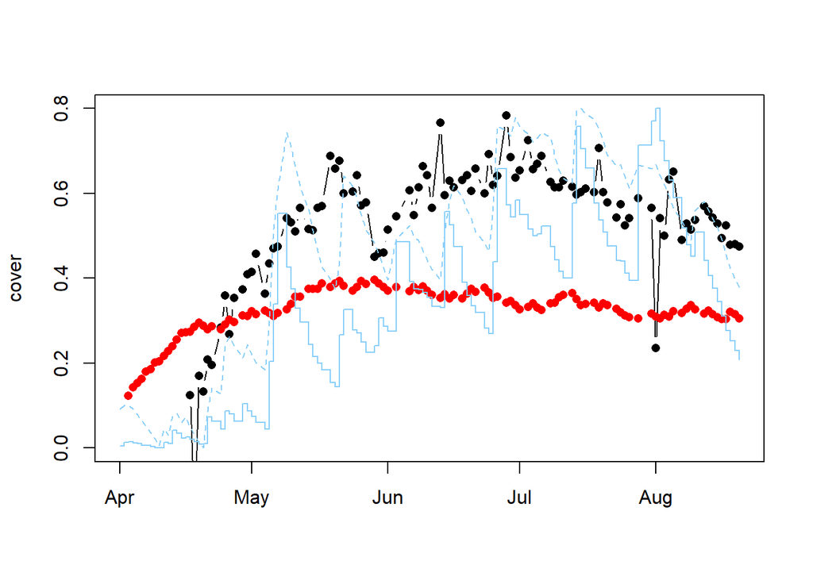

Fig 1. Hufkens model performance in PACE: Lucerne (control). The blue line marks rainfall (irrigation) without showing the axis.

It seems the scale is off. so we can tweek the optimal temperature (from 33 to 17)

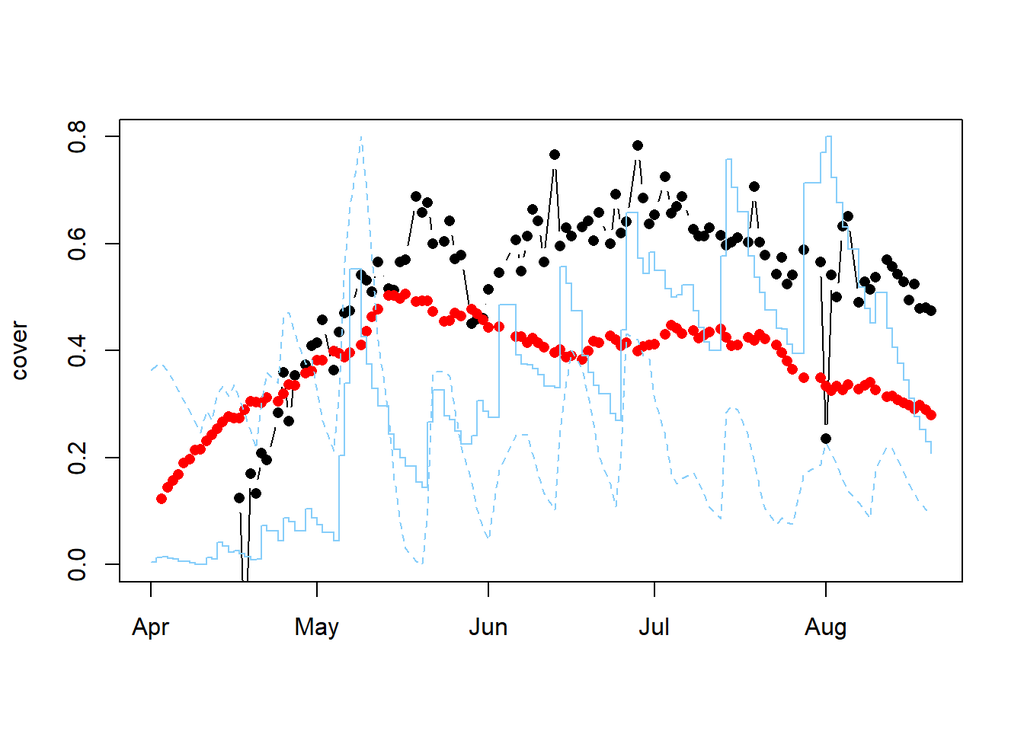

Fig 2. Hufekns with optimal temperature of 17 degree C.

Of course we can change the wilting point and capacity but it will dramatically worsen the model performace. Hufken used something like 120 and 400. If we use those numbers we have:

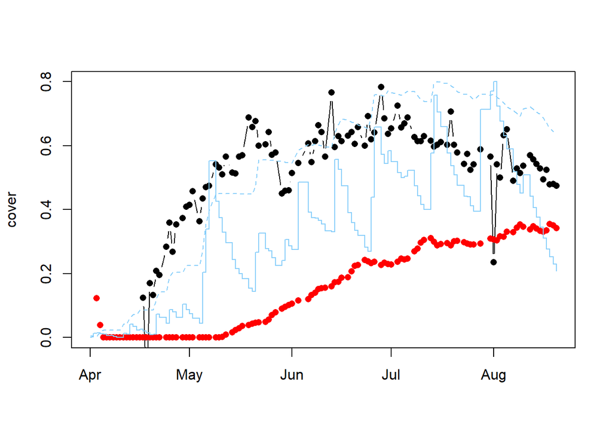

Fig 3. Hufekns with realistic soil moisture capacity and wilting point.

Note that the issue of the capacity and wilting point also suggests issues with the soil water bucket size.